# Learning from Data: An R workflow

T. Neeman

May 2022

## Learning from Data

### Erythrocyte-Platelet complex formation

We have developed an assay to measure the formation of platelet-mediated erythrocyte-parasite complexes in the presence of P. falciparum infected erythrocytes, expressed as the percentage of erythrocytes (out of 500) that have formed complexes. We tested our assay using:

- infected and uninfected erythrocytes,
- 3 different platelet:erythrocyte concentration ratios (0.02:1, 0.2:1, and 2:1),
- 2 different incubation times (2 hours - baseline and 24 hours - final).

We ran the experiment FIVE times. We would like to see if our new assay shows that malaria-infected red blood cells (RBC) induce complex formation.

Data from our experiment: “complex formation.csv”

### R workflow:

We organise our analyses in R as follows:

0. make sure spreadsheet is properly formatted.
1. Preparation: import libraries that we’ll need for the analyses.
2. Set-up: import the data set, and do some initial checks.
3. Data management: set data types/ restructure/subset data as needed.
4. Data exploration: visualisation for assessing patterns/associations.
5. Fit statistical model:
   1. assess model assumptions
   2. statistical inference
   3. obtain estimates of treatment effects (plus/minus uncertainty)
6. Graphical or tabular summary of statistical model.

### Set up libraries

```r
library(tidyverse)
library(lmerTest)
library(emmeans)
library(ggResidpanel)
```

## Import data and check data structure

We can check the data structure either using the function str() or glimpse()

```r
ery <- read_csv("data/complex formation.csv") %>%
  mutate(time = factor(time, levels = c("2h","24h")))
```

How many observations for each Experiment, infection status, concentration ratio and incubation time? Remember to use group_by() and summarise(). Can you use pivot_wider() to make the table easier to read?

```r
ery %>%
  group_by(Experiment, RBC, time, ratio) %>%
  summarise(count = n()) %>%
  pivot_wider(names_from = Experiment, values_from = count)
```

```
## # A tibble: 12 × 8
## # Groups:   RBC, time [4]
##    RBC        time  ratio    `1`   `2`   `3`   `4`   `5`
##    <chr>      <fct> <chr>  <int> <int> <int> <int> <int>
##  1 infected   2h    0.02:1     4     4     4     4     4
##  2 infected   2h    0.2:1      4     4     4     4     4
##  3 infected   2h    r2:1       4     4     4     4     4
##  4 infected   24h   0.02:1     4     4     4     4     4
##  5 infected   24h   0.2:1      4     4     4     4     4
##  6 infected   24h   r2:1       4     4     4     4     4
##  7 uninfected 2h    0.02:1     4     4     4     4     4
##  8 uninfected 2h    0.2:1      4     4     4     4     4
##  9 uninfected 2h    r2:1       4     4     4     4     4
## 10 uninfected 24h   0.02:1     4     4     4     4     4
## 11 uninfected 24h   0.2:1      4     4     4     4     4
## 12 uninfected 24h   r2:1       4     4     4     4     4
```

## Data exploration

Think of a few different ways to explore your data, keeping mind your research question. We would like to know if infected cells induce complex formation. Be sensitive to the order within factors, and change factor levels, if needed.

You might try a few different plots instead of just a single plot.

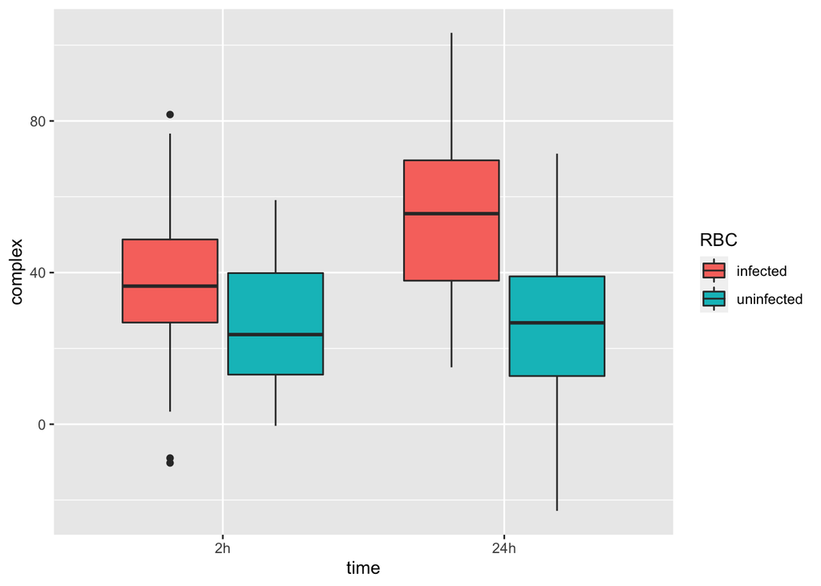

```r
ggplot(ery, aes(x = time, y = complex, fill = RBC)) +
  geom_boxplot()
```

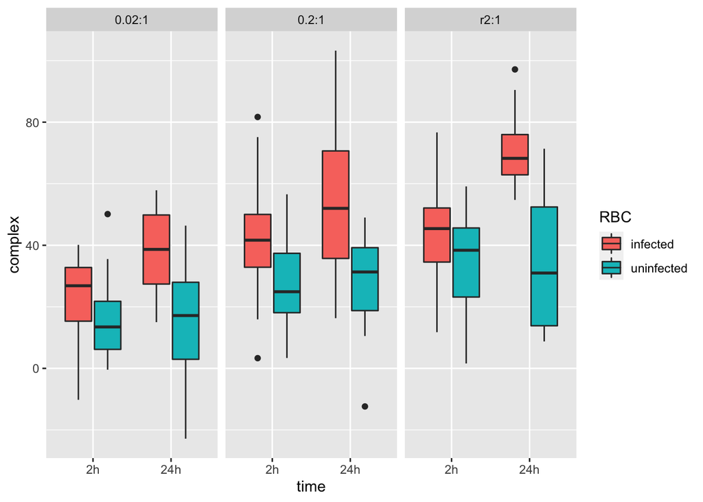

```r
ggplot(ery, aes(x = time, y = complex, fill = RBC)) +
  geom_boxplot()+
  facet_wrap(~ratio)
```

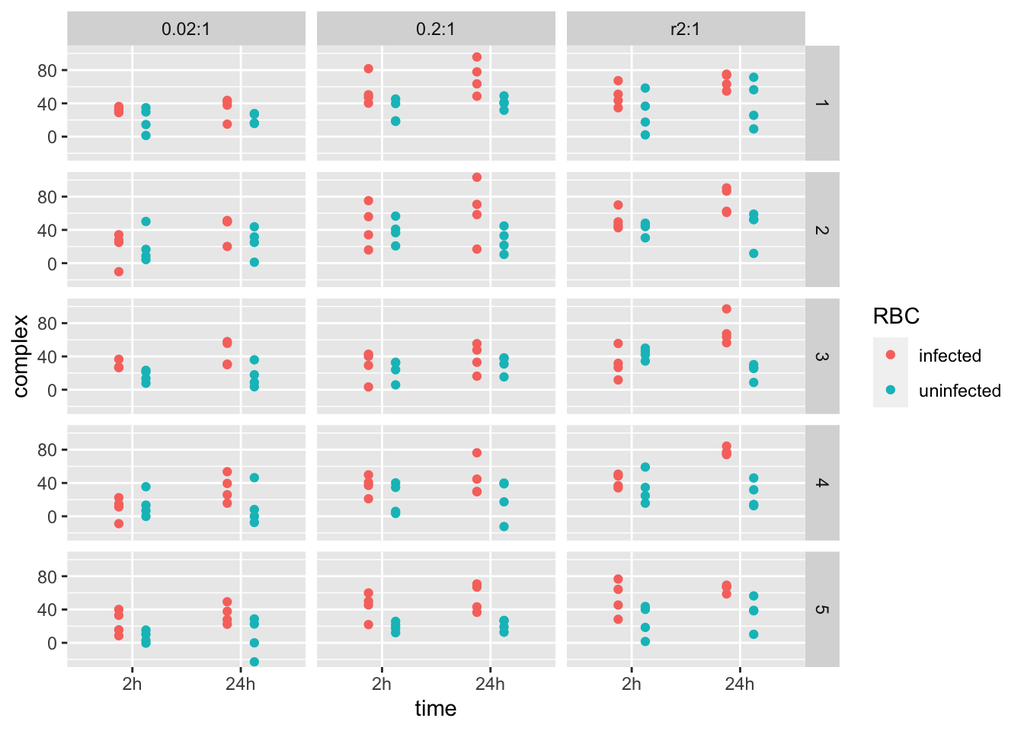

```r
ggplot(ery, aes(x = time, y = complex, col = RBC)) +
  geom_point(position = position_dodge(width = .5))+
  facet_grid(Experiment~ratio)
```

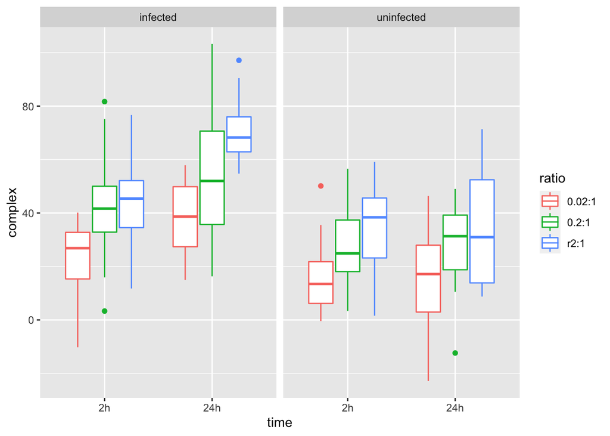

```r
ggplot(ery, aes(x = time, y = complex, col = ratio)) +
  geom_boxplot()+
  facet_wrap(~RBC)
```

Fit a model to these data to address the research question. Include Experiment as a blocking factor

```r
lm.ery<-lmer(complex~ time*RBC*ratio + (1|Experiment), data=ery)
```

Use the anova() function to get the ANOVA table. Interpret the table.

```r
anova(lm.ery)
```

```
## Type III Analysis of Variance Table with Satterthwaite's method
##                 Sum Sq Mean Sq NumDF DenDF F value    Pr(>F)
## time            4917.7  4917.7     1   224 19.0131 1.980e-05 ***
## RBC            23464.6 23464.6     1   224 90.7204 < 2.2e-16 ***
## ratio          22008.2 11004.1     2   224 42.5449 < 2.2e-16 ***
## time:RBC        4293.3  4293.3     1   224 16.5989 6.411e-05 ***
## time:ratio       343.8   171.9     2   224  0.6646    0.5155
## RBC:ratio        990.3   495.2     2   224  1.9144    0.1498
## time:RBC:ratio   685.7   342.9     2   224  1.3256    0.2677
## ---
## Signif. codes:  0 '***' 0.001 '**' 0.01 '*' 0.05 '.' 0.1 ' ' 1
```

Looking at your exploratory graphs, we can start to piece together the story the data are telling.

Typically, we look at the highest level interactions first. They tell us about interesting patterns. If an interaction is “statistically significant”, but the main effect is not, it could be that the individual effects (contrasts) average out to 0.

(I1) Time:RBC interaction: There is a difference in the incubation time effect between infected and uninfected RBC (averaged across ratio) and across Experiment. This is what we are hoping to see! Describe this difference.

In the absence of treatment interactions, we can describe the main effects.

(M1) There is a platelet:erythrocyte ratio effect. This is estimated as the effect of ratio, averaged across the other 2 conditions (time, RBC) and across Experiments. Referring to your graph, describe that pattern.

(M2) There is an incubation time effect. This is estimated as the effect of incubation time, averaged across the other 2 conditions (ratio, RBC) and across Experiments. Referring to your graph, describe that pattern.

(M3) There is an infection effect. This is estimated as the difference between infected and uninfected RBC, averaged across the other 2 conditions (time, ratio) and across Experiments. Referring to your graph, describe that pattern.

Assess model assumptions with residual plots

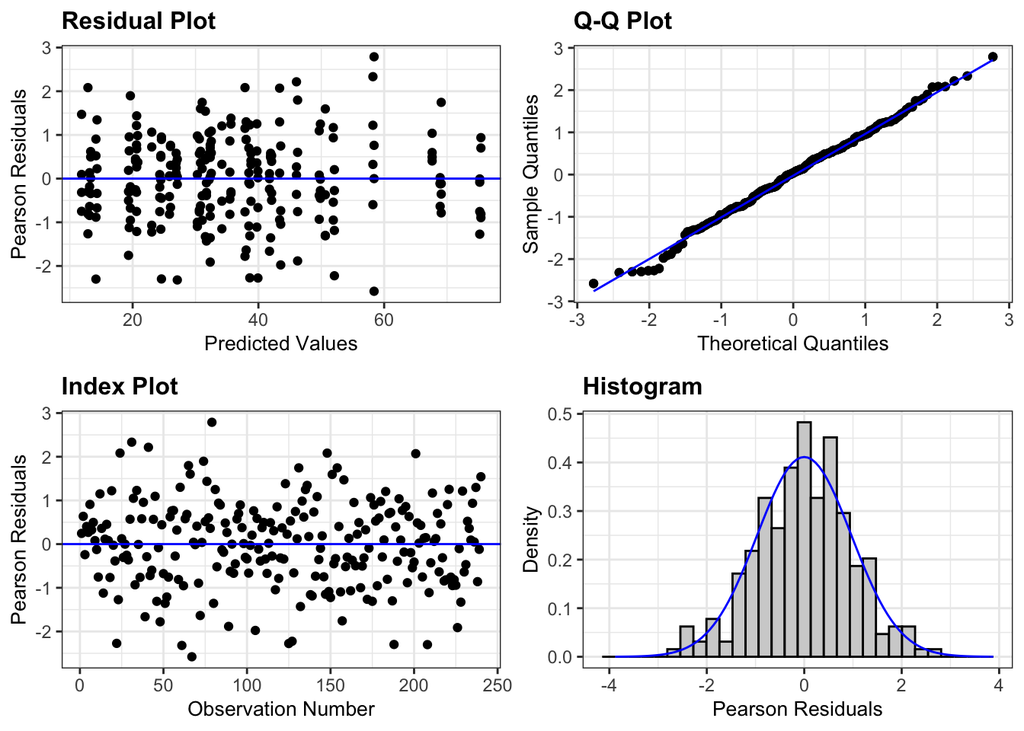

```r
resid_panel(lm.ery)
```

Look at parameter estimates and between-Experiment variation using the summary() function

```r
summary(lm.ery)
```

```
## Linear mixed model fit by REML. t-tests use Satterthwaite's method [
## lmerModLmerTest]
## Formula: complex ~ time * RBC * ratio + (1 | Experiment)
##    Data: ery
##
## REML criterion at convergence: 1955.5
##
## Scaled residuals:
##     Min      1Q  Median      3Q     Max
## -2.5791 -0.6686  0.0401  0.6208  2.7888
##
## Random effects:
##  Groups     Name        Variance Std.Dev.
##  Experiment (Intercept)  18.18    4.264
##  Residual               258.65   16.083
## Number of obs: 240, groups:  Experiment, 5
##
## Fixed effects:
##                                  Estimate Std. Error      df t value Pr(>|t|)
## (Intercept)                        22.954      4.070  44.409   5.639 1.11e-06
## time24h                            14.846      5.086 224.000   2.919 0.003869
## RBCuninfected                      -7.465      5.086 224.000  -1.468 0.143573
## ratio0.2:1                         19.136      5.086 224.000   3.763 0.000215
## ratior2:1                          22.759      5.086 224.000   4.475 1.22e-05
## time24h:RBCuninfected             -13.839      7.192 224.000  -1.924 0.055604
## time24h:ratio0.2:1                 -2.685      7.192 224.000  -0.373 0.709308
## time24h:ratior2:1                  10.684      7.192 224.000   1.485 0.138818
## RBCuninfected:ratio0.2:1           -7.978      7.192 224.000  -1.109 0.268488
## RBCuninfected:ratior2:1            -3.578      7.192 224.000  -0.497 0.619375
## time24h:RBCuninfected:ratio0.2:1    3.222     10.171 224.000   0.317 0.751750
## time24h:RBCuninfected:ratior2:1   -12.458     10.171 224.000  -1.225 0.221929
##
## (Intercept)                      ***
## time24h                          **
## RBCuninfected
## ratio0.2:1                       ***
## ratior2:1                        ***
## time24h:RBCuninfected            .
## time24h:ratio0.2:1
## time24h:ratior2:1
```

[output cut: 17 more lines]

[output not shown]

Obtain mean estimates and standard errors for plotting using the emmeans() function

```r
results1<-summary(emmeans(lm.ery,~time*RBC*ratio))
results1
```

```
##  time RBC        ratio  emmean   SE   df lower.CL upper.CL
##  2h   infected   0.02:1   23.0 4.07 44.4    14.75     31.2
##  24h  infected   0.02:1   37.8 4.07 44.4    29.60     46.0
##  2h   uninfected 0.02:1   15.5 4.07 44.4     7.29     23.7
##  24h  uninfected 0.02:1   16.5 4.07 44.4     8.29     24.7
##  2h   infected   0.2:1    42.1 4.07 44.4    33.89     50.3
##  24h  infected   0.2:1    54.3 4.07 44.4    46.05     62.5
##  2h   uninfected 0.2:1    26.6 4.07 44.4    18.45     34.8
##  24h  uninfected 0.2:1    28.2 4.07 44.4    19.99     36.4
##  2h   infected   r2:1     45.7 4.07 44.4    37.51     53.9
##  24h  infected   r2:1     71.2 4.07 44.4    63.04     79.4
##  2h   uninfected r2:1     34.7 4.07 44.4    26.47     42.9
##  24h  uninfected r2:1     33.9 4.07 44.4    25.70     42.1
##
## Degrees-of-freedom method: kenward-roger
## Confidence level used: 0.95
```

Finally, create a graphic summarising the model

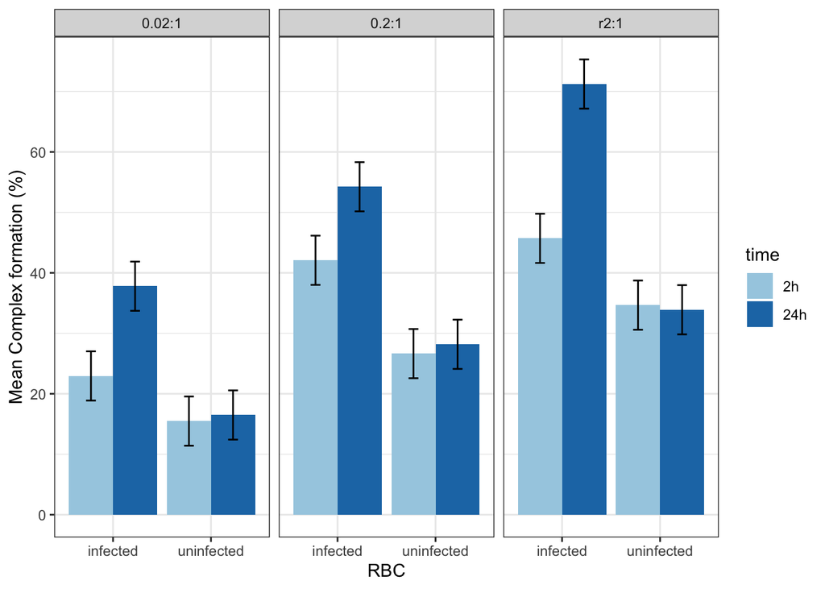

```r
ggplot(results1, aes(x=RBC, y=emmean, fill = time)) +
  geom_bar(stat="identity", position = "dodge") +
  geom_errorbar(aes(ymin = emmean-SE, ymax=emmean+SE),width=0.2, position=position_dodge(width=0.9))+
  facet_wrap(~ratio)+
  scale_fill_brewer(palette = "Paired")+
  ylab("Mean Complex formation (%)")+
  theme_bw()
```